# …

# Reaction Time

Next, let’s look at the **reaction time** (RT) data. All reaction times presented here are log-transformed reaction times.

This plot shows the relationship between RT and Singlish score for all trials. Essentially, even if the particular clip was not chosen as the More Singlish clip in that trial, its RT (i.e., the time it took for the *other* clip in the trial to be selected as the More Singlish clip, which is also the time it took for the particular clip in question to be *not* selected) is also represented in this plot.

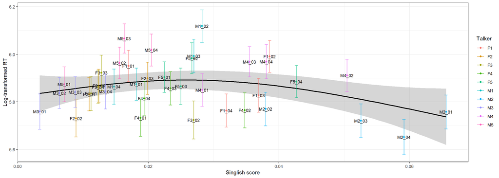

```r
ggplot(tab.rt_all, aes(x=clip_score, y=mean, label=clip)) +
  geom_point(aes(x=clip_score, y=mean, color=speaker), stat="identity") +
  geom_smooth(method="gam", color="black") +
  geom_text(size=3) +
  geom_errorbar(aes(x=clip_score, ymin=mean-ic, ymax=mean+ic, color=speaker), width=0.0005, alpha=0.6, linewidth=0.7) +
  labs(x="Singlish score", y="Log-transformed RT", color="Talker")
```

We also want to look at the relationship between RT and Singlish score, but only for those clips which were chosen as the More Singlish clip.

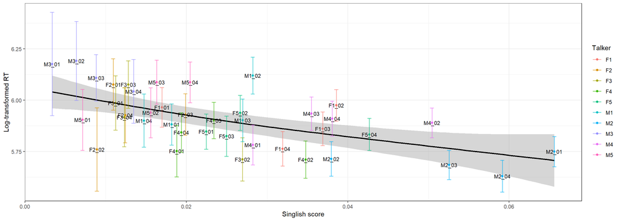

```r
ggplot(tab.rt_ones, aes(x=clip_score, y=mean, label=clip)) +
  geom_point(aes(x=clip_score, y=mean, color=speaker), stat="identity") +
  geom_smooth(method="gam", color = "black") +
  geom_text(size=3) +
  geom_errorbar(aes(x=clip_score, ymin=mean-ic, ymax=mean+ic, color=speaker), width=0.0005, alpha=0.6, linewidth=0.7) +
  labs(x="Singlish score", y="Log-transformed RT", color="Talker")
```

Now, we run a linear mixed effects regression model with RT as the dependent variable and Singlish score as the fixed effect, with by-participant slope for clip score. This model shows that clips with a higher Singlish score were chosen as the More Singlish clip with a significantly faster RT.

```r
m.rt_ones = lmer(logRT ~ clip_score + (1|speaker) + (1 + clip_score|id), data=df.rt_ones)
summary(m.rt_ones)
```

```
## Linear mixed model fit by REML. t-tests use Satterthwaite's method [
## lmerModLmerTest]
## Formula: logRT ~ clip_score + (1 | speaker) + (1 + clip_score | id)
##    Data: df.rt_ones
##
## REML criterion at convergence: 35501.7
##
## Scaled residuals:
##     Min      1Q  Median      3Q     Max
## -7.2799 -0.4004  0.0506  0.5492  3.2031
##
## Random effects:
##  Groups   Name        Variance Std.Dev. Corr
##  id       (Intercept)  0.23255 0.48223
##           clip_score  16.65713 4.08131  -0.48
##  speaker  (Intercept)  0.00885 0.09407
##  Residual              0.71542 0.84582
## Number of obs: 13976, groups:  id, 132; speaker, 10
##
## Fixed effects:
##              Estimate Std. Error        df t value Pr(>|t|)
## (Intercept)   5.93079    0.05728  63.20447 103.540   <2e-16 ***
## clip_score   -2.04625    0.96216 315.74006  -2.127   0.0342 *
## ---
## Signif. codes:  0 '***' 0.001 '**' 0.01 '*' 0.05 '.' 0.1 ' ' 1
##
## Correlation of Fixed Effects:
##            (Intr)
## clip_score -0.516
```

Next, we want to model the relationship between RT and Singlish score for all the stimuli, not just those which were chosen as the More Singlish clip. We use a generalized additive model with random smooths because of our relatively simple random effects structure and the non-linear relationship between RT and Singlish score.

```r
m.rt_all = gam(logRT ~ s(clip_score, bs="cr") + s(clip_score, id, bs="re") + s(speaker, bs="re"), data=df.rt_all, method="REML")
summary(m.rt_all)
```

```
##
## Family: gaussian
## Link function: identity
##
## Formula:
## logRT ~ s(clip_score, bs = "cr") + s(clip_score, id, bs = "re") +
##     s(speaker, bs = "re")
##
## Parametric coefficients:
##             Estimate Std. Error t value Pr(>|t|)
## (Intercept)  5.85140    0.03679   159.1   <2e-16 ***
## ---
## Signif. codes:  0 '***' 0.001 '**' 0.01 '*' 0.05 '.' 0.1 ' ' 1
##
## Approximate significance of smooth terms:
##                      edf  Ref.df      F p-value
## s(clip_score)      3.790   4.602  3.257 0.00646 **
## s(clip_score,id) 127.015 131.000 36.109 < 2e-16 ***
## s(speaker)         8.345   9.000 15.424 < 2e-16 ***
## ---
## Signif. codes:  0 '***' 0.001 '**' 0.01 '*' 0.05 '.' 0.1 ' ' 1
##
## R-sq.(adj) =   0.15   Deviance explained = 15.4%
## -REML =  36254  Scale est. = 0.76922   n = 27952
```

And here’s a partial effect plot showing the effect of smooth term of Singlish score on RT:

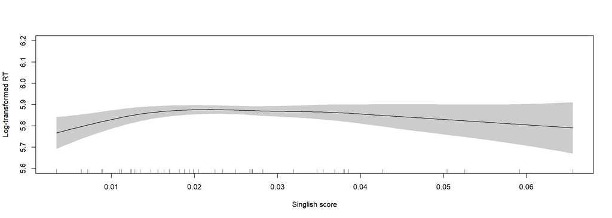

```r
plot(m.rt_all, select=1, shade=TRUE, shift=coef(m.rt_all)[1], ylim=c(5.6, 6.2), ylab="Log-transformed RT", xlab="Singlish score", rug=TRUE)
```

# Acoustic Analysis

From listeners’ open-ended responses in the questionnaire, we selected four **acoustic features** to analyze: pitch Pairwise Variability Index (PVI), pitch variance, durational PVI, and articulation rate. Each clip was annotated for all of these features. The centered values of these acoustic features for each of the 40 clips are already appended in the data frame that’s associated with this Rmd file.

We run a logistic mixed effects regression model with response as the dependent variable (i.e., whether or not the clip was chosen as the More Singlish clip), the four acoustic features as fixed effects, and random intercepts of clip and speaker.

The model also includes theoretically justified interactions between speech rate and pitch PVI, between pitch variance and pitch PVI, and between durational PVI and pitch PVI. Participant was not included as a random effect because the proportion of responses for each participant is even (i.e., all participants had the same number of “1”s and “0”s for responses, given the design of the experiment); a model including participant as a random effect produced a singular fit error.

```r
m.singlish = glmer(singlish ~ csyllablespersec + cst_pitchpvi_new + cstvar_new + cnpviV_nophrasefinal + csyllablespersec:cst_pitchpvi_new + cstvar_new:cst_pitchpvi_new + cnpviV_nophrasefinal:cst_pitchpvi_new + (1|clip) + (1|speaker), data=df.singlish_pairs, family=binomial())
summary(m.singlish)
```

```
## Generalized linear mixed model fit by maximum likelihood (Laplace
##   Approximation) [glmerMod]
##  Family: binomial  ( logit )
## Formula: singlish ~ csyllablespersec + cst_pitchpvi_new + cstvar_new +
##     cnpviV_nophrasefinal + csyllablespersec:cst_pitchpvi_new +
##     cstvar_new:cst_pitchpvi_new + cnpviV_nophrasefinal:cst_pitchpvi_new +
##     (1 | clip) + (1 | speaker)
##    Data: df.singlish_pairs
##
##      AIC      BIC   logLik deviance df.resid
##  33607.8  33690.2 -16793.9  33587.8    27942
##
## Scaled residuals:
##     Min      1Q  Median      3Q     Max
## -3.4161 -0.8010 -0.0237  0.8392  2.9398
##
## Random effects:
##  Groups  Name        Variance Std.Dev.
##  clip    (Intercept) 0.1800   0.4242
##  speaker (Intercept) 0.9126   0.9553
## Number of obs: 27952, groups:  clip, 40; speaker, 10
##
## Fixed effects:
##                                         Estimate Std. Error z value Pr(>|z|)
## (Intercept)                            0.0318118  0.3159236   0.101   0.9198
## csyllablespersec                       0.2142222  0.1056513   2.028   0.0426 *
## cst_pitchpvi_new                       0.1904631  0.0913463   2.085   0.0371 *
## cstvar_new                            -0.1950189  0.0859976  -2.268   0.0233 *
## cnpviV_nophrasefinal                   0.0008625  0.0066610   0.129   0.8970
## csyllablespersec:cst_pitchpvi_new      0.0702686  0.0866115   0.811   0.4172
## cst_pitchpvi_new:cstvar_new           -0.0027752  0.0421698  -0.066   0.9475
## cst_pitchpvi_new:cnpviV_nophrasefinal -0.0028094  0.0048506  -0.579   0.5625
## ---
## Signif. codes:  0 '***' 0.001 '**' 0.01 '*' 0.05 '.' 0.1 ' ' 1
##
## Correlation of Fixed Effects:
##             (Intr) csyllb cst_p_ cstvr_ cnpvV_ csy:__ cs__:_
## csyllblsprs  0.049
## cst_ptchpv_  0.081  0.630
## cstvar_new  -0.029 -0.509 -0.639
## cnpvV_nphrs  0.026 -0.028 -0.026  0.241
## csyllbls:__  0.085  0.361  0.533 -0.408  0.126
## cst_ptch_:_ -0.114 -0.044 -0.089 -0.190 -0.173  0.164
## cst_ptc_:V_  0.018 -0.012  0.051 -0.103 -0.250 -0.249  0.082
```

The model shows that articulation rate, pitch PVI, and pitch variance are significant predictors of a More Singlish response. Let’s plot the predictions from this model:

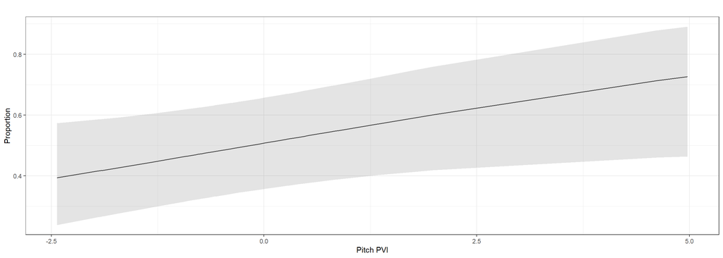

```r
# predicted probabilities of Singlish score based on pitch PVI (centered) values
plot_model(m.singlish, type="pred", terms="cst_pitchpvi_new [all]", color=gray.colors(5)) +
  labs(x="Pitch PVI", y="Proportion", title="") +
  scale_y_continuous(breaks=y_axis_values, labels=y_axis_labels)
```

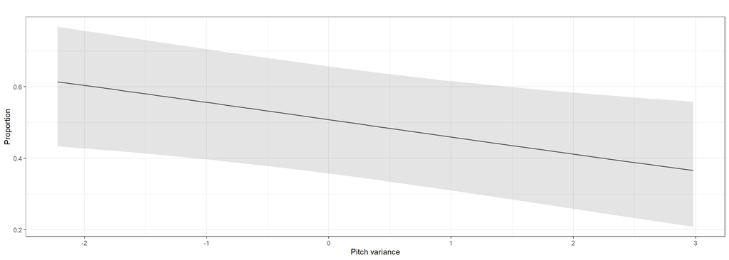

```r
# predicted probabilities of Singlish score based on pitch variance (centered) values
plot_model(m.singlish, type="pred", terms="cstvar_new [all]", color=gray.colors(5)) +
  labs(x="Pitch variance", y="Proportion", title="") +
  scale_y_continuous(breaks=y_axis_values, labels=y_axis_labels)
```

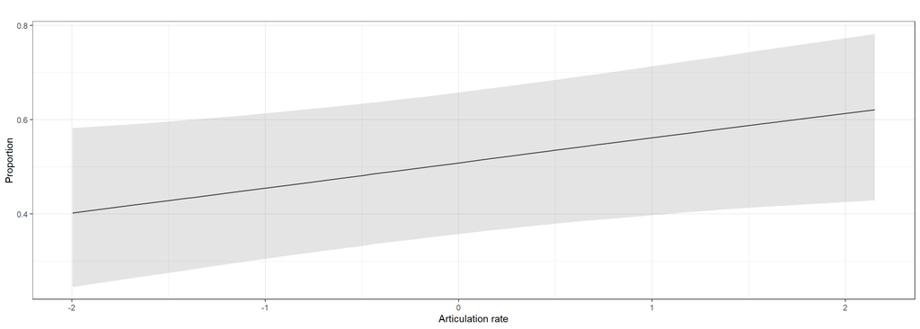

```r
# predicted probabilities of Singlish score based on articulation rate (centered) values
plot_model(m.singlish, type="pred", terms="csyllablespersec [all]", color=gray.colors(5)) +
  labs(x="Articulation rate", y="Proportion", title="") +
  scale_y_continuous(breaks=y_axis_values, labels=y_axis_labels)
```

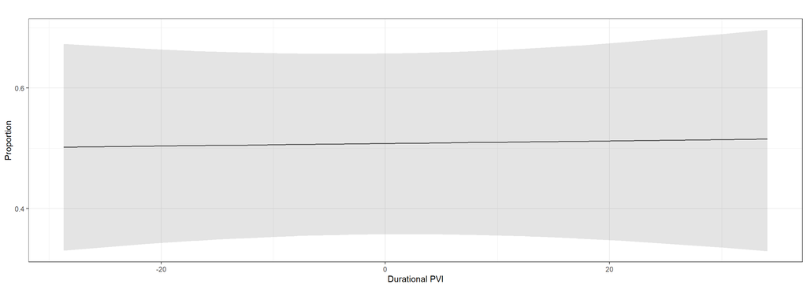

```r
# predicted probabilities of Singlish score based on durational PVI (centered) values *NS)
plot_model(m.singlish, type="pred", terms="cnpviV_nophrasefinal [all]", color=gray.colors(5)) +
  labs(x="Durational PVI", y="Proportion", title="") +
  scale_y_continuous(breaks=y_axis_values, labels=y_axis_labels)
```

# Relative perception

In this section, we look at how listeners’ attention to differences between the two clips affects categorization, in terms of both response choice and response time.

## RT and difference in Singlish score

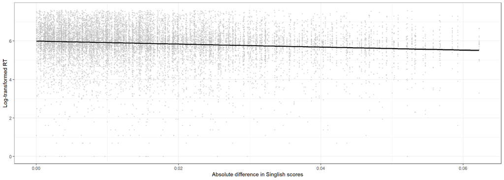

```r
ggplot(df.singlish_scorediff, aes(x = abs_score_difference, y = logRT)) +
  geom_point(size = 0.5, color = "gray", alpha = 0.5) +
  labs(x = "Absolute difference in Singlish scores", y = "Log-transformed RT") +
  geom_smooth(method = "lm", se = TRUE, color = "black")
```

We ran a linear mixed effects regression model to test the relationship between differences in Singlish score and RT:

```r
m.singlish_scorediff <- lmer(logRT ~ abs_score_difference + (1|clip) + (1|speaker) + (abs_score_difference|id), data = df.singlish_scorediff)
summary(m.singlish_scorediff)
```

```
## Linear mixed model fit by REML. t-tests use Satterthwaite's method [
## lmerModLmerTest]
## Formula:
## logRT ~ abs_score_difference + (1 | clip) + (1 | speaker) + (abs_score_difference |
##     id)
##    Data: df.singlish_scorediff
##
## REML criterion at convergence: 35374.4
##
## Scaled residuals:
##     Min      1Q  Median      3Q     Max
## -7.3084 -0.4034  0.0540  0.5398  3.2328
##
## Random effects:
##  Groups   Name                 Variance  Std.Dev. Corr
##  id       (Intercept)           0.207179 0.45517
##           abs_score_difference 25.894915 5.08870  -0.33
##  clip     (Intercept)           0.006897 0.08305
##  speaker  (Intercept)           0.005255 0.07249
##  Residual                       0.706450 0.84051
## Number of obs: 13976, groups:  id, 132; clip, 40; speaker, 10
##
## Fixed effects:
##                       Estimate Std. Error        df t value Pr(>|t|)
## (Intercept)            5.98200    0.04968  64.10251 120.409  < 2e-16 ***
## abs_score_difference  -7.43059    0.92143 290.19642  -8.064 1.95e-14 ***
## ---
## Signif. codes:  0 '***' 0.001 '**' 0.01 '*' 0.05 '.' 0.1 ' ' 1
##
## Correlation of Fixed Effects:
##             (Intr)
## abs_scr_dff -0.327
```

## Response choice and difference in acoustic features

The next two models look at the relationship between the likelihood of being chosen as the More Singlish clip and the magnitude and directionality of difference in acoustic values between the current clip and the other clip in the same trial. These two models use the **raw difference in acoustic features**, and so directionality is encoded in the estimates.

The following includes the all the fixed effects from the previous model + the difference between acoustic features within a trial:

```r
m.singlish_pairs_1 = glmer(singlish ~  csyllablespersec + cst_pitchpvi_new + cstvar_new + cnpviV_nophrasefinal + csyllablespersec:cst_pitchpvi_new + cstvar_new:cst_pitchpvi_new + cnpviV_nophrasefinal:cst_pitchpvi_new + csyllablespersec_diff_c + cst_pitchpvi_new_diff_c + cstvar_new_diff_c + cnpviV_nophrasefinal_diff_c + (1|clip) + (1|speaker), data=df.singlish_pairs, family=binomial())
summary(m.singlish_pairs_1)
```

```
## Generalized linear mixed model fit by maximum likelihood (Laplace
##   Approximation) [glmerMod]
##  Family: binomial  ( logit )
## Formula: singlish ~ csyllablespersec + cst_pitchpvi_new + cstvar_new +
##     cnpviV_nophrasefinal + csyllablespersec:cst_pitchpvi_new +
##     cstvar_new:cst_pitchpvi_new + cnpviV_nophrasefinal:cst_pitchpvi_new +
##     csyllablespersec_diff_c + cst_pitchpvi_new_diff_c + cstvar_new_diff_c +
##     cnpviV_nophrasefinal_diff_c + (1 | clip) + (1 | speaker)
##    Data: df.singlish_pairs
##
##      AIC      BIC   logLik deviance df.resid
##  33414.2  33529.5 -16693.1  33386.2    27937
##
## Scaled residuals:
##     Min      1Q  Median      3Q     Max
## -4.0717 -0.7879 -0.2788  0.8081  3.5746
##
## Random effects:
##  Groups  Name        Variance Std.Dev.
##  clip    (Intercept) 0.1812   0.4257
##  speaker (Intercept) 0.9255   0.9620
## Number of obs: 27951, groups:  clip, 40; speaker, 10
##
## Fixed effects:
##                                         Estimate Std. Error z value Pr(>|z|)
## (Intercept)                            0.0305729  0.3161149   0.097  0.92295
## csyllablespersec                       0.0264947  0.1072413   0.247  0.80486
## cst_pitchpvi_new                       0.1705364  0.0923671   1.846  0.06485
## cstvar_new                            -0.2301308  0.0872570  -2.637  0.00835
## cnpviV_nophrasefinal                  -0.0005323  0.0067647  -0.079  0.93728
## csyllablespersec_diff_c                0.1854452  0.0161146  11.508  < 2e-16
## cst_pitchpvi_new_diff_c                0.0217265  0.0113504   1.914  0.05560
## cstvar_new_diff_c                      0.0317456  0.0130430   2.434  0.01494
## cnpviV_nophrasefinal_diff_c            0.0012429  0.0010394   1.196  0.23178
## csyllablespersec:cst_pitchpvi_new      0.0694951  0.0869033   0.800  0.42389
## cst_pitchpvi_new:cstvar_new           -0.0022903  0.0422930  -0.054  0.95681
## cst_pitchpvi_new:cnpviV_nophrasefinal -0.0027162  0.0048674  -0.558  0.57682
##
## (Intercept)
## csyllablespersec
```

[output cut: 26 more lines]

```
##             csy:__ cs__:_
## csyllblsprs
## cst_ptchpv_
## cstvar_new
## cnpvV_nphrs
## csyllblsp__
## cst_ptch___
## cstvr_nw_d_
## cnpvV_nph__
## csyllbls:__
## cst_ptch_:_  0.164
## cst_ptc_:V_ -0.249  0.082
## optimizer (Nelder_Mead) convergence code: 0 (OK)
## Model is nearly unidentifiable: very large eigenvalue
##  - Rescale variables?
```

The following model only includes the difference between acoustic features within a trial as a predictor:

```r
m.singlish_pairs_2 = glmer(singlish ~ csyllablespersec_diff_c + cst_pitchpvi_new_diff_c + cstvar_new_diff_c + cnpviV_nophrasefinal_diff_c + (1|clip) + (1|speaker), data=df.singlish_pairs, family=binomial())
summary(m.singlish_pairs_2)
```

```
## Generalized linear mixed model fit by maximum likelihood (Laplace
##   Approximation) [glmerMod]
##  Family: binomial  ( logit )
## Formula: singlish ~ csyllablespersec_diff_c + cst_pitchpvi_new_diff_c +
##     cstvar_new_diff_c + cnpviV_nophrasefinal_diff_c + (1 | clip) +
##     (1 | speaker)
##    Data: df.singlish_pairs
##
##      AIC      BIC   logLik deviance df.resid
##  33409.3  33467.0 -16697.7  33395.3    27944
##
## Scaled residuals:
##     Min      1Q  Median      3Q     Max
## -4.0207 -0.7864 -0.2784  0.8087  3.5706
##
## Random effects:
##  Groups  Name        Variance Std.Dev.
##  clip    (Intercept) 0.2613   0.5111
##  speaker (Intercept) 0.7493   0.8656
## Number of obs: 27951, groups:  clip, 40; speaker, 10
##
## Fixed effects:
##                             Estimate Std. Error z value Pr(>|z|)
## (Intercept)                 0.007443   0.285322   0.026   0.9792
## csyllablespersec_diff_c     0.185241   0.015957  11.609   <2e-16 ***
## cst_pitchpvi_new_diff_c     0.024326   0.011274   2.158   0.0310 *
## cstvar_new_diff_c           0.027540   0.012962   2.125   0.0336 *
## cnpviV_nophrasefinal_diff_c 0.001213   0.001029   1.179   0.2386
## ---
## Signif. codes:  0 '***' 0.001 '**' 0.01 '*' 0.05 '.' 0.1 ' ' 1
##
## Correlation of Fixed Effects:
##             (Intr) csyl__ cs____ cst___
## csyllblsp__  0.000
## cst_ptch___  0.000  0.482
## cstvr_nw_d_  0.000 -0.422 -0.576
## cnpvV_nph__  0.000 -0.002  0.030  0.244
## optimizer (Nelder_Mead) convergence code: 0 (OK)
## Model is nearly unidentifiable: very large eigenvalue
##  - Rescale variables?
```

We then compare the two models:

```r
anova(m.singlish_pairs_1, m.singlish_pairs_2, test="LRT")
```

```
## Data: df.singlish_pairs
## Models:
## m.singlish_pairs_2: singlish ~ csyllablespersec_diff_c + cst_pitchpvi_new_diff_c + cstvar_new_diff_c + cnpviV_nophrasefinal_diff_c + (1 | clip) + (1 | speaker)
## m.singlish_pairs_1: singlish ~ csyllablespersec + cst_pitchpvi_new + cstvar_new + cnpviV_nophrasefinal + csyllablespersec:cst_pitchpvi_new + cstvar_new:cst_pitchpvi_new + cnpviV_nophrasefinal:cst_pitchpvi_new + csyllablespersec_diff_c + cst_pitchpvi_new_diff_c + cstvar_new_diff_c + cnpviV_nophras…
##                    npar   AIC   BIC logLik deviance  Chisq Df Pr(>Chisq)
## m.singlish_pairs_2    7 33409 33467 -16698    33395
## m.singlish_pairs_1   14 33414 33530 -16693    33386 9.0976  7     0.2457
```

Since the more complex model is not a better predictor of the data, we will go with the simpler model, `m.singlish_pairs_2` which includes only the difference in values of the acoustic features as fixed effects.

### Alternative: Interaction instead of difference

One alternative way of looking at this is by including the interactions between the acoustic features of the two clips in a given trial as fixed effects, instead of using the difference in acoustic features:

```r
m.singlish_pairs_3 = glmer(singlish ~ csyllablespersec + cst_pitchpvi_new + cstvar_new + cnpviV_nophrasefinal + csyllablespersec:cst_pitchpvi_new + cstvar_new:cst_pitchpvi_new + cnpviV_nophrasefinal:cst_pitchpvi_new + csyllablespersec:csyllablespersec_pair + cstvar_new:cstvar_new_pair + cst_pitchpvi_new:cst_pitchpvi_new_pair + cnpviV_nophrasefinal:cnpviV_nophrasefinal_pair + (1|clip) + (1|speaker), data=df.singlish_pairs)
summary(m.singlish_pairs_3)
```

```
## Linear mixed model fit by REML ['lmerMod']
## Formula: singlish ~ csyllablespersec + cst_pitchpvi_new + cstvar_new +
##     cnpviV_nophrasefinal + csyllablespersec:cst_pitchpvi_new +
##     cstvar_new:cst_pitchpvi_new + cnpviV_nophrasefinal:cst_pitchpvi_new +
##     csyllablespersec:csyllablespersec_pair + cstvar_new:cstvar_new_pair +
##     cst_pitchpvi_new:cst_pitchpvi_new_pair + cnpviV_nophrasefinal:cnpviV_nophrasefinal_pair +
##     (1 | clip) + (1 | speaker)
##    Data: df.singlish_pairs
##
## REML criterion at convergence: 35446.1
##
## Scaled residuals:
##     Min      1Q  Median      3Q     Max
## -2.0477 -0.8630 -0.2119  0.9123  1.9909
##
## Random effects:
##  Groups   Name        Variance Std.Dev.
##  clip     (Intercept) 0.01004  0.1002
##  speaker  (Intercept) 0.04267  0.2066
##  Residual             0.20610  0.4540
## Number of obs: 27951, groups:  clip, 40; speaker, 10
##
## Fixed effects:
##                                                  Estimate Std. Error t value
## (Intercept)                                     5.037e-01  6.834e-02   7.370
## csyllablespersec                                4.315e-02  2.472e-02   1.746
## cst_pitchpvi_new                                3.715e-02  2.110e-02   1.761
## cstvar_new                                     -3.610e-02  1.976e-02  -1.828
## cnpviV_nophrasefinal                           -1.840e-04  1.550e-03  -0.119
## csyllablespersec:cst_pitchpvi_new               9.291e-03  1.988e-02   0.467
## cst_pitchpvi_new:cstvar_new                    -9.969e-04  9.725e-03  -0.103
## cst_pitchpvi_new:cnpviV_nophrasefinal          -3.281e-04  1.136e-03  -0.289
## csyllablespersec:csyllablespersec_pair         -6.546e-04  3.017e-03  -0.217
## cstvar_new:cstvar_new_pair                     -2.199e-03  1.583e-03  -1.390
## cst_pitchpvi_new:cst_pitchpvi_new_pair          1.144e-03  1.276e-03   0.896
## cnpviV_nophrasefinal:cnpviV_nophrasefinal_pair -3.377e-06  1.580e-05  -0.214
##
## Correlation of Fixed Effects:
##             (Intr) csyllb cst_p_ cstvr_ cnpvV_ csy:__ cs__:_ c__:V_ csyl:_
## csyllblsprs  0.054
## cst_ptchpv_  0.087  0.631
## cstvar_new  -0.033 -0.509 -0.629
## cnpvV_nphrs  0.025 -0.028 -0.026  0.240
## csyllbls:__  0.093  0.360  0.516 -0.383  0.133
## cst_ptch_:_ -0.122 -0.054 -0.115 -0.159 -0.161  0.138
## cst_ptc_:V_  0.020 -0.014  0.043 -0.093 -0.245 -0.266  0.072
## csyllblsp:_  0.001 -0.001 -0.001  0.002  0.001 -0.002 -0.001  0.000
## cstvr_nw:__  0.000  0.000 -0.002  0.002  0.000  0.002  0.003  0.000  0.020
## cst_pt_:___  0.000  0.001  0.003 -0.003 -0.001 -0.003  0.005  0.001 -0.093
## cnpvV_n:V__  0.000  0.000  0.000  0.000  0.002 -0.001 -0.002 -0.001  0.028
##             cs_:__ c__:__
## csyllblsprs
## cst_ptchpv_
## cstvar_new
## cnpvV_nphrs
## csyllbls:__
## cst_ptch_:_
## cst_ptc_:V_
## csyllblsp:_
## cstvr_nw:__
## cst_pt_:___ -0.223
## cnpvV_n:V__ -0.096  0.000
```

```r
m.singlish_pairs_4 = glmer(singlish ~ csyllablespersec:csyllablespersec_pair + cstvar_new:cstvar_new_pair + cst_pitchpvi_new:cst_pitchpvi_new_pair + cnpviV_nophrasefinal:cnpviV_nophrasefinal_pair + (1|clip) + (1|speaker), data=df.singlish_pairs)
summary(m.singlish_pairs_4)
```

```
## Linear mixed model fit by REML ['lmerMod']
## Formula:
## singlish ~ csyllablespersec:csyllablespersec_pair + cstvar_new:cstvar_new_pair +
##     cst_pitchpvi_new:cst_pitchpvi_new_pair + cnpviV_nophrasefinal:cnpviV_nophrasefinal_pair +
##     (1 | clip) + (1 | speaker)
##    Data: df.singlish_pairs
##
## REML criterion at convergence: 35395.7
##
## Scaled residuals:
##     Min      1Q  Median      3Q     Max
## -2.0456 -0.8666 -0.2115  0.9131  1.9912
##
## Random effects:
##  Groups   Name        Variance Std.Dev.
##  clip     (Intercept) 0.009707 0.09852
##  speaker  (Intercept) 0.038774 0.19691
##  Residual             0.206097 0.45398
## Number of obs: 27951, groups:  clip, 40; speaker, 10
##
## Fixed effects:
##                                                  Estimate Std. Error t value
## (Intercept)                                     4.998e-01  6.425e-02   7.779
## csyllablespersec:csyllablespersec_pair         -6.466e-04  3.017e-03  -0.214
## cstvar_new:cstvar_new_pair                     -2.190e-03  1.583e-03  -1.384
## cst_pitchpvi_new:cst_pitchpvi_new_pair          1.130e-03  1.276e-03   0.885
## cnpviV_nophrasefinal:cnpviV_nophrasefinal_pair -3.428e-06  1.580e-05  -0.217
##
## Correlation of Fixed Effects:
##             (Intr) csyl:_ cs_:__ c__:__
## csyllblsp:_  0.001
## cstvr_nw:__  0.001  0.020
## cst_pt_:___  0.001 -0.093 -0.223
## cnpvV_n:V__  0.000  0.028 -0.096  0.000
```

Both models don’t show any significant effects, but we can compare them anyway:

```r
anova(m.singlish_pairs_3, m.singlish_pairs_4, test="LRT")
```

```
## refitting model(s) with ML (instead of REML)
```

```
## Data: df.singlish_pairs
## Models:
## m.singlish_pairs_4: singlish ~ csyllablespersec:csyllablespersec_pair + cstvar_new:cstvar_new_pair + cst_pitchpvi_new:cst_pitchpvi_new_pair + cnpviV_nophrasefinal:cnpviV_nophrasefinal_pair + (1 | clip) + (1 | speaker)
## m.singlish_pairs_3: singlish ~ csyllablespersec + cst_pitchpvi_new + cstvar_new + cnpviV_nophrasefinal + csyllablespersec:cst_pitchpvi_new + cstvar_new:cst_pitchpvi_new + cnpviV_nophrasefinal:cst_pitchpvi_new + csyllablespersec:csyllablespersec_pair + cstvar_new:cstvar_new_pair + cst_pitchpvi_new…
##                    npar   AIC   BIC logLik deviance  Chisq Df Pr(>Chisq)
## m.singlish_pairs_4    8 35355 35421 -17670    35339
## m.singlish_pairs_3   15 35363 35487 -17667    35333 6.0578  7      0.533
```

## RT and difference in acoustic features

The next two models examine the relationship between RT of a trial and the difference in values of acoustic features between the current clip and the other clip in the trial. Here, we use the **absolute difference** in acoustic features.

The following includes the all the fixed effects from the acoustic model + the difference between acoustic features within a trial:

```r
m.singlish_pairs_5 = lmer(logRT ~ csyllablespersec + cst_pitchpvi_new + cstvar_new + cnpviV_nophrasefinal + csyllablespersec:cst_pitchpvi_new + cstvar_new:cst_pitchpvi_new + cnpviV_nophrasefinal:cst_pitchpvi_new + csyllablespersec_diff_c_abs + cst_pitchpvi_new_diff_c_abs + cstvar_new_diff_c_abs + cnpviV_nophrasefinal_diff_c_abs + (1|clip) + (1|speaker), data=df.singlish_pairs)
summary(m.singlish_pairs_5)
```

```
## Linear mixed model fit by REML. t-tests use Satterthwaite's method [
## lmerModLmerTest]
## Formula:
## logRT ~ csyllablespersec + cst_pitchpvi_new + cstvar_new + cnpviV_nophrasefinal +
##     csyllablespersec:cst_pitchpvi_new + cstvar_new:cst_pitchpvi_new +
##     cnpviV_nophrasefinal:cst_pitchpvi_new + csyllablespersec_diff_c_abs +
##     cst_pitchpvi_new_diff_c_abs + cstvar_new_diff_c_abs + cnpviV_nophrasefinal_diff_c_abs +
##     (1 | clip) + (1 | speaker)
##    Data: df.singlish_pairs
##
## REML criterion at convergence: 76419.6
##
## Scaled residuals:
##     Min      1Q  Median      3Q     Max
## -6.3327 -0.3629  0.0943  0.6015  1.9946
##
## Random effects:
##  Groups   Name        Variance Std.Dev.
##  clip     (Intercept) 0.004662 0.06828
##  speaker  (Intercept) 0.003986 0.06314
##  Residual             0.896035 0.94659
## Number of obs: 27951, groups:  clip, 40; speaker, 10
##
## Fixed effects:
##                                         Estimate Std. Error         df t value
## (Intercept)                            5.845e+00  2.915e-02  1.877e+01 200.537
## csyllablespersec                      -1.868e-02  1.791e-02  2.949e+01  -1.043
## cst_pitchpvi_new                       1.128e-02  1.482e-02  3.167e+01   0.761
## cstvar_new                            -3.643e-03  1.444e-02  2.974e+01  -0.252
## cnpviV_nophrasefinal                  -6.010e-04  1.135e-03  2.832e+01  -0.530
## csyllablespersec_diff_c_abs            2.349e-03  7.762e-03  1.155e+04   0.303
## cst_pitchpvi_new_diff_c_abs            8.664e-03  4.805e-03  2.393e+04   1.803
## cstvar_new_diff_c_abs                  1.531e-02  5.550e-03  2.074e+04   2.759
## cnpviV_nophrasefinal_diff_c_abs       -8.897e-04  5.664e-04  1.336e+04  -1.571
## csyllablespersec:cst_pitchpvi_new      9.849e-03  1.458e-02  2.892e+01   0.676
## cst_pitchpvi_new:cstvar_new            3.520e-03  7.141e-03  3.247e+01   0.493
## cst_pitchpvi_new:cnpviV_nophrasefinal  1.082e-03  8.445e-04  2.605e+01   1.282
##                                       Pr(>|t|)
## (Intercept)                             <2e-16 ***
## csyllablespersec                        0.3055
```

[output cut: 23 more lines]

```
## csyllbls:__  0.112  0.330  0.466 -0.337  0.142  0.074  0.085 -0.028  0.052
## cst_ptch_:_ -0.200 -0.060 -0.135 -0.116 -0.145  0.059 -0.143 -0.078  0.092
## cst_ptc_:V_  0.019  0.016  0.056 -0.106 -0.272 -0.004  0.049 -0.012  0.033
##             csy:__ cs__:_
## csyllblsprs
## cst_ptchpv_
## cstvar_new
## cnpvV_nphrs
## csyllbls___
## cst_ptc____
## cstvr_nw___
## cnpvV_np___
## csyllbls:__
## cst_ptch_:_  0.115
## cst_ptc_:V_ -0.271  0.062
```

This second model only includes the absolute difference in values of the acoustic features as fixed effects:

```r
m.singlish_pairs_6 = lmer(logRT ~ csyllablespersec_diff_c_abs + cst_pitchpvi_new_diff_c_abs + cstvar_new_diff_c_abs + cnpviV_nophrasefinal_diff_c_abs + (1|clip) + (1|speaker), data=df.singlish_pairs)
summary(m.singlish_pairs_6)
```

```
## Linear mixed model fit by REML. t-tests use Satterthwaite's method [
## lmerModLmerTest]
## Formula: logRT ~ csyllablespersec_diff_c_abs + cst_pitchpvi_new_diff_c_abs +
##     cstvar_new_diff_c_abs + cnpviV_nophrasefinal_diff_c_abs +
##     (1 | clip) + (1 | speaker)
##    Data: df.singlish_pairs
##
## REML criterion at convergence: 76366.5
##
## Scaled residuals:
##     Min      1Q  Median      3Q     Max
## -6.3382 -0.3634  0.0945  0.6020  1.9773
##
## Random effects:
##  Groups   Name        Variance Std.Dev.
##  clip     (Intercept) 0.004399 0.06633
##  speaker  (Intercept) 0.004813 0.06937
##  Residual             0.896030 0.94659
## Number of obs: 27951, groups:  clip, 40; speaker, 10
##
## Fixed effects:
##                                   Estimate Std. Error         df t value
## (Intercept)                      5.840e+00  2.943e-02  1.732e+01 198.397
## csyllablespersec_diff_c_abs      1.519e-03  7.719e-03  9.879e+03   0.197
## cst_pitchpvi_new_diff_c_abs      8.581e-03  4.612e-03  3.439e+03   1.861
## cstvar_new_diff_c_abs            1.596e-02  5.454e-03  8.293e+03   2.926
## cnpviV_nophrasefinal_diff_c_abs -8.485e-04  5.575e-04  6.315e+03  -1.522
##                                 Pr(>|t|)
## (Intercept)                      < 2e-16 ***
## csyllablespersec_diff_c_abs      0.84405
## cst_pitchpvi_new_diff_c_abs      0.06287 .
## cstvar_new_diff_c_abs            0.00344 **
## cnpviV_nophrasefinal_diff_c_abs  0.12810
## ---
## Signif. codes:  0 '***' 0.001 '**' 0.01 '*' 0.05 '.' 0.1 ' ' 1
##
## Correlation of Fixed Effects:
##             (Intr) csy___ c_____ cs____
## csyllbls___ -0.264
## cst_ptc____ -0.215  0.016
## cstvr_nw___ -0.242 -0.029 -0.163
## cnpvV_np___ -0.273 -0.087 -0.004  0.035
```

We then compare the two models:

```r
anova(m.singlish_pairs_5, m.singlish_pairs_6, test="LRT")
```

```
## refitting model(s) with ML (instead of REML)
```

```
## Data: df.singlish_pairs
## Models:
## m.singlish_pairs_6: logRT ~ csyllablespersec_diff_c_abs + cst_pitchpvi_new_diff_c_abs + cstvar_new_diff_c_abs + cnpviV_nophrasefinal_diff_c_abs + (1 | clip) + (1 | speaker)
## m.singlish_pairs_5: logRT ~ csyllablespersec + cst_pitchpvi_new + cstvar_new + cnpviV_nophrasefinal + csyllablespersec:cst_pitchpvi_new + cstvar_new:cst_pitchpvi_new + cnpviV_nophrasefinal:cst_pitchpvi_new + csyllablespersec_diff_c_abs + cst_pitchpvi_new_diff_c_abs + cstvar_new_diff_c_abs + cnpvi…
##                    npar   AIC   BIC logLik deviance  Chisq Df Pr(>Chisq)
## m.singlish_pairs_6    8 76338 76404 -38161    76322
## m.singlish_pairs_5   15 76345 76468 -38157    76315 7.7075  7     0.3591
```

Next, we want to decide what is the optimal random effects structure for our RT model, since our first RT model (`m.rt_ones`) included random by-participant slope and intercept for the relevant fixed effect, but `m.singlish_pairs_6` only includes random intercepts of clip and speaker.

This next model therefore incorporates random by-participant slopes and intercepts for the absolute difference in acoustic features between two clips in a given trial:

```r
m.singlish_pairs_7 = lmer(logRT ~ csyllablespersec_diff_c_abs + cst_pitchpvi_new_diff_c_abs + cstvar_new_diff_c_abs + cnpviV_nophrasefinal_diff_c_abs + (1 + csyllablespersec_diff_c_abs|id) + (1 + cst_pitchpvi_new_diff_c_abs|id) + (1 + cstvar_new_diff_c_abs|id) + (1 + cnpviV_nophrasefinal_diff_c_abs|id) + (1|clip) + (1|speaker), data=df.singlish_pairs)
summary(m.singlish_pairs_7)
```

```
## Linear mixed model fit by REML. t-tests use Satterthwaite's method [
## lmerModLmerTest]
## Formula: logRT ~ csyllablespersec_diff_c_abs + cst_pitchpvi_new_diff_c_abs +
##     cstvar_new_diff_c_abs + cnpviV_nophrasefinal_diff_c_abs +
##     (1 + csyllablespersec_diff_c_abs | id) + (1 + cst_pitchpvi_new_diff_c_abs |
##     id) + (1 + cstvar_new_diff_c_abs | id) + (1 + cnpviV_nophrasefinal_diff_c_abs |
##     id) + (1 | clip) + (1 | speaker)
##    Data: df.singlish_pairs
##
## REML criterion at convergence: 70537.6
##
## Scaled residuals:
##     Min      1Q  Median      3Q     Max
## -7.3249 -0.4108  0.0439  0.5431  3.2670
##
## Random effects:
##  Groups   Name                            Variance  Std.Dev. Corr
##  id       (Intercept)                     1.045e-02 0.102249
##           csyllablespersec_diff_c_abs     4.922e-03 0.070158 -0.99
##  id.1     (Intercept)                     1.023e-01 0.319882
##           cst_pitchpvi_new_diff_c_abs     1.285e-03 0.035850 -0.10
##  id.2     (Intercept)                     9.155e-02 0.302573
##           cstvar_new_diff_c_abs           1.396e-03 0.037361 -0.17
##  id.3     (Intercept)                     2.546e-02 0.159563
##           cnpviV_nophrasefinal_diff_c_abs 3.714e-05 0.006094 -0.95
##  clip     (Intercept)                     5.068e-03 0.071193
##  speaker  (Intercept)                     4.553e-03 0.067474
##  Residual                                 7.050e-01 0.839630
## Number of obs: 27951, groups:  id, 132; clip, 40; speaker, 10
##
## Fixed effects:
##                                   Estimate Std. Error         df t value
## (Intercept)                      5.819e+00  5.059e-02  9.402e+01 115.032
## csyllablespersec_diff_c_abs      7.798e-03  9.359e-03  1.461e+02   0.833
## cst_pitchpvi_new_diff_c_abs      6.581e-03  5.251e-03  1.754e+02   1.253
## cstvar_new_diff_c_abs            1.363e-02  5.940e-03  1.482e+02   2.294
## cnpviV_nophrasefinal_diff_c_abs -1.168e-03  7.382e-04  1.334e+02  -1.582
##                                 Pr(>|t|)
## (Intercept)                       <2e-16 ***
## csyllablespersec_diff_c_abs       0.4060
## cst_pitchpvi_new_diff_c_abs       0.2118
## cstvar_new_diff_c_abs             0.0232 *
## cnpviV_nophrasefinal_diff_c_abs   0.1160
## ---
## Signif. codes:  0 '***' 0.001 '**' 0.01 '*' 0.05 '.' 0.1 ' ' 1
##
## Correlation of Fixed Effects:
##             (Intr) csy___ c_____ cs____
## csyllbls___ -0.221
## cst_ptc____ -0.125  0.009
## cstvr_nw___ -0.157 -0.017 -0.109
## cnpvV_np___ -0.290 -0.046 -0.002  0.019
## optimizer (nloptwrap) convergence code: 0 (OK)
## unable to evaluate scaled gradient
## Model failed to converge: degenerate  Hessian with 1 negative eigenvalues
```

Comparing the model with simplified random effects (`m.singlish_pairs_6`) versus the one with a more complex random effects structure (`m.singlish_pairs_7`):

```r
anova(m.singlish_pairs_6, m.singlish_pairs_7, test="LRT")
```

```
## refitting model(s) with ML (instead of REML)
```

```
## Data: df.singlish_pairs
## Models:
## m.singlish_pairs_6: logRT ~ csyllablespersec_diff_c_abs + cst_pitchpvi_new_diff_c_abs + cstvar_new_diff_c_abs + cnpviV_nophrasefinal_diff_c_abs + (1 | clip) + (1 | speaker)
## m.singlish_pairs_7: logRT ~ csyllablespersec_diff_c_abs + cst_pitchpvi_new_diff_c_abs + cstvar_new_diff_c_abs + cnpviV_nophrasefinal_diff_c_abs + (1 + csyllablespersec_diff_c_abs | id) + (1 + cst_pitchpvi_new_diff_c_abs | id) + (1 + cstvar_new_diff_c_abs | id) + (1 + cnpviV_nophrasefinal_diff_c_a…
##                    npar   AIC   BIC logLik deviance  Chisq Df Pr(>Chisq)
## m.singlish_pairs_6    8 76338 76404 -38161    76322
## m.singlish_pairs_7   20 70536 70701 -35248    70496 5826.2 12  < 2.2e-16 ***
## ---
## Signif. codes:  0 '***' 0.001 '**' 0.01 '*' 0.05 '.' 0.1 ' ' 1
```

We see that `m.singlish_pairs_7`, the model with a more complex random effects structure, is significantly better than the simpler model. Therefore, we go with `m.singlish_pairs_7`.

### Alternative: Interaction instead of difference

Another way of thinking about RT and relative perception is by looking at the interaction between the acoustic feature values of the two clips in a trial.

```r
m.singlish_pairs_8 = lmer(logRT ~ csyllablespersec + cst_pitchpvi_new + cstvar_new + cnpviV_nophrasefinal + csyllablespersec:cst_pitchpvi_new + cstvar_new:cst_pitchpvi_new + cnpviV_nophrasefinal:cst_pitchpvi_new + csyllablespersec:csyllablespersec_pair + cstvar_new:cstvar_new_pair + cst_pitchpvi_new:cst_pitchpvi_new_pair + cnpviV_nophrasefinal:cnpviV_nophrasefinal_pair + (1|clip) + (1|speaker), data=df.singlish_pairs)
summary(m.singlish_pairs_8)
```

```
## Linear mixed model fit by REML. t-tests use Satterthwaite's method [
## lmerModLmerTest]
## Formula:
## logRT ~ csyllablespersec + cst_pitchpvi_new + cstvar_new + cnpviV_nophrasefinal +
##     csyllablespersec:cst_pitchpvi_new + cstvar_new:cst_pitchpvi_new +
##     cnpviV_nophrasefinal:cst_pitchpvi_new + csyllablespersec:csyllablespersec_pair +
##     cstvar_new:cstvar_new_pair + cst_pitchpvi_new:cst_pitchpvi_new_pair +
##     cnpviV_nophrasefinal:cnpviV_nophrasefinal_pair + (1 | clip) +
##     (1 | speaker)
##    Data: df.singlish_pairs
##
## REML criterion at convergence: 76436.6
##
## Scaled residuals:
##     Min      1Q  Median      3Q     Max
## -6.3271 -0.3631  0.0933  0.6002  2.0082
##
## Random effects:
##  Groups   Name        Variance Std.Dev.
##  clip     (Intercept) 0.004734 0.06880
##  speaker  (Intercept) 0.003637 0.06031
##  Residual             0.896319 0.94674
## Number of obs: 27951, groups:  clip, 40; speaker, 10
##
## Fixed effects:
##                                                  Estimate Std. Error         df
## (Intercept)                                     5.866e+00  2.432e-02  1.028e+01
## csyllablespersec                               -1.793e-02  1.784e-02  2.918e+01
## cst_pitchpvi_new                                1.099e-02  1.474e-02  3.143e+01
## cstvar_new                                     -8.870e-04  1.433e-02  2.881e+01
## cnpviV_nophrasefinal                           -8.165e-04  1.133e-03  2.820e+01
## csyllablespersec:cst_pitchpvi_new               9.305e-03  1.449e-02  2.834e+01
## cst_pitchpvi_new:cstvar_new                     8.494e-03  6.990e-03  2.988e+01
## cst_pitchpvi_new:cnpviV_nophrasefinal           1.073e-03  8.465e-04  2.609e+01
## csyllablespersec:csyllablespersec_pair         -7.766e-03  6.291e-03  2.792e+04
## cstvar_new:cstvar_new_pair                     -5.990e-03  3.300e-03  2.792e+04
## cst_pitchpvi_new:cst_pitchpvi_new_pair         -9.858e-04  2.661e-03  2.792e+04
## cnpviV_nophrasefinal:cnpviV_nophrasefinal_pair  4.342e-05  3.295e-05  2.792e+04
##                                                t value Pr(>|t|)
## (Intercept)                                    241.167   <2e-16 ***
```

[output cut: 24 more lines]

```
## cstvr_nw:__  0.002  0.000 -0.004  0.005  0.000  0.005  0.008 -0.001  0.020
## cst_pt_:___  0.000  0.003  0.009 -0.007 -0.003 -0.008  0.015  0.001 -0.093
## cnpvV_n:V__  0.001  0.002  0.002 -0.001  0.006 -0.003 -0.004 -0.002  0.028
##             cs_:__ c__:__
## csyllblsprs
## cst_ptchpv_
## cstvar_new
## cnpvV_nphrs
## csyllbls:__
## cst_ptch_:_
## cst_ptc_:V_
## csyllblsp:_
## cstvr_nw:__
## cst_pt_:___ -0.223
## cnpvV_n:V__ -0.096  0.000
```

```r
m.singlish_pairs_9 = lmer(logRT ~ csyllablespersec:csyllablespersec_pair + cstvar_new:cstvar_new_pair + cst_pitchpvi_new:cst_pitchpvi_new_pair + cnpviV_nophrasefinal:cnpviV_nophrasefinal_pair + (1|clip) + (1|speaker), data=df.singlish_pairs)
summary(m.singlish_pairs_9)
```

```
## Linear mixed model fit by REML. t-tests use Satterthwaite's method [
## lmerModLmerTest]
## Formula:
## logRT ~ csyllablespersec:csyllablespersec_pair + cstvar_new:cstvar_new_pair +
##     cst_pitchpvi_new:cst_pitchpvi_new_pair + cnpviV_nophrasefinal:cnpviV_nophrasefinal_pair +
##     (1 | clip) + (1 | speaker)
##    Data: df.singlish_pairs
##
## REML criterion at convergence: 76384.5
##
## Scaled residuals:
##     Min      1Q  Median      3Q     Max
## -6.3270 -0.3628  0.0943  0.5997  1.9831
##
## Random effects:
##  Groups   Name        Variance Std.Dev.
##  clip     (Intercept) 0.004524 0.06726
##  speaker  (Intercept) 0.004911 0.07008
##  Residual             0.896319 0.94674
## Number of obs: 27951, groups:  clip, 40; speaker, 10
##
## Fixed effects:
##                                                  Estimate Std. Error         df
## (Intercept)                                     5.866e+00  2.523e-02  8.997e+00
## csyllablespersec:csyllablespersec_pair         -7.725e-03  6.290e-03  2.793e+04
## cstvar_new:cstvar_new_pair                     -6.020e-03  3.300e-03  2.793e+04
## cst_pitchpvi_new:cst_pitchpvi_new_pair         -1.042e-03  2.660e-03  2.794e+04
## cnpviV_nophrasefinal:cnpviV_nophrasefinal_pair  4.388e-05  3.295e-05  2.792e+04
##                                                t value Pr(>|t|)
## (Intercept)                                    232.553   <2e-16 ***
## csyllablespersec:csyllablespersec_pair          -1.228   0.2194
## cstvar_new:cstvar_new_pair                      -1.825   0.0681 .
## cst_pitchpvi_new:cst_pitchpvi_new_pair          -0.392   0.6953
## cnpviV_nophrasefinal:cnpviV_nophrasefinal_pair   1.332   0.1830
## ---
## Signif. codes:  0 '***' 0.001 '**' 0.01 '*' 0.05 '.' 0.1 ' ' 1
##
## Correlation of Fixed Effects:
##             (Intr) csyl:_ cs_:__ c__:__
## csyllblsp:_  0.005
## cstvr_nw:__  0.003  0.020
## cst_pt_:___  0.006 -0.093 -0.223
## cnpvV_n:V__  0.001  0.028 -0.096  0.000
```

We then compare the two models:

```r
anova(m.singlish_pairs_8, m.singlish_pairs_9, test="LRT")
```

```
## refitting model(s) with ML (instead of REML)
```

```
## Data: df.singlish_pairs
## Models:
## m.singlish_pairs_9: logRT ~ csyllablespersec:csyllablespersec_pair + cstvar_new:cstvar_new_pair + cst_pitchpvi_new:cst_pitchpvi_new_pair + cnpviV_nophrasefinal:cnpviV_nophrasefinal_pair + (1 | clip) + (1 | speaker)
## m.singlish_pairs_8: logRT ~ csyllablespersec + cst_pitchpvi_new + cstvar_new + cnpviV_nophrasefinal + csyllablespersec:cst_pitchpvi_new + cstvar_new:cst_pitchpvi_new + cnpviV_nophrasefinal:cst_pitchpvi_new + csyllablespersec:csyllablespersec_pair + cstvar_new:cstvar_new_pair + cst_pitchpvi_new:cs…
##                    npar   AIC   BIC logLik deviance  Chisq Df Pr(>Chisq)
## m.singlish_pairs_9    8 76348 76414 -38166    76332
## m.singlish_pairs_8   15 76353 76477 -38162    76323 8.9503  7     0.2562
```